# 01d. ITS2 single-end, paired-end 및 BLAST 통합 비교

QC20 / maxEE 2,2 — Cutadapt와 ITSxpress

2026-10-16

# 1 1. 분석 질문과 범위

본 보고서는 동일한 83개 library를 네 preprocessing pipeline으로 처리한 결과와 `Aureobasidium` 대표 서열의 NCBI BLAST 결과를 한 보고서에서 연결한다.

1. Single-end와 paired-end 중 어느 쪽이 read와 ASV를 더 많이 보존하는가?
2. Cutadapt와 ITSxpress 차이가 read mode에 따라 달라지는가?
3. 네 pipeline의 community structure와 species profile은 어느 정도 일치하는가?
4. Cutadapt에서 `Aureobasidium tremulum`으로 분류된 우점 ASV가 single-end와 BLAST에서는 어떻게 보이는가?

이 보고서는 전처리 방법 비교이다. Rarefaction, abundance filtering 및 decontam은 적용하지 않았으며, BLAST hit는 taxonomy 검증에 사용했을 뿐 새로운 ASV 제거 기준으로 사용하지 않았다.

## 1.1 비교 설계

| Trimming | Single-end | Paired-end |
| --- | --- | --- |
| Cutadapt | Cutadapt Single | Cutadapt Paired |
| ITSxpress | ITSxpress Single | ITSxpress Paired |

- Primary comparison: 동일 trimming 내 Single vs Paired
- Orthogonal comparison: 동일 read mode 내 Cutadapt vs ITSxpress
- BLAST validation: Cutadapt 303-bp 대표 ASV와 동일 read pattern에서 얻은 155-bp ITS2 core
- 모든 통계는 동일 SampleID를 연결한 기술적 pipeline 비교이며 독립 biological group 검정이 아니다.

# 2 2. 입력 자료 및 전처리 audit

| Method | Stage | Samples | Taxa | Total_Reads |
| --- | --- | --- | --- | --- |
| Cutadapt Single | Imported ASV table | 83 | 1860 | 1169781 |
| Cutadapt Single | Taxonomy cleaned | 83 | 1860 | 1169781 |
| Cutadapt Single | Kingdom == Fungi retained | 83 | 1860 | 1169781 |
| Cutadapt Single | Zero-sum samples/taxa removed | 83 | 1860 | 1169781 |
| Cutadapt Paired | Imported ASV table | 83 | 1301 | 954579 |
| Cutadapt Paired | Taxonomy cleaned | 83 | 1301 | 954579 |
| Cutadapt Paired | Kingdom == Fungi retained | 83 | 1301 | 954579 |
| Cutadapt Paired | Zero-sum samples/taxa removed | 83 | 1301 | 954579 |
| ITSxpress Single | Imported ASV table | 83 | 1202 | 960334 |
| ITSxpress Single | Taxonomy cleaned | 83 | 1202 | 960334 |

[output cut: 6 more lines]

네 pipeline 모두 83개 library가 유지되었으며, `Kingdom == Fungi`와 zero-sum 제거 외에 추가 ASV abundance threshold는 적용하지 않았다.

## 2.1 최종 ASV와 read 수

| Method | Samples | ASVs | Total_Reads |
| --- | --- | --- | --- |
| Cutadapt Single | 83 | 1860 | 1169781 |
| Cutadapt Paired | 83 | 1301 | 954579 |
| ITSxpress Single | 83 | 1202 | 960334 |
| ITSxpress Paired | 83 | 1215 | 536398 |

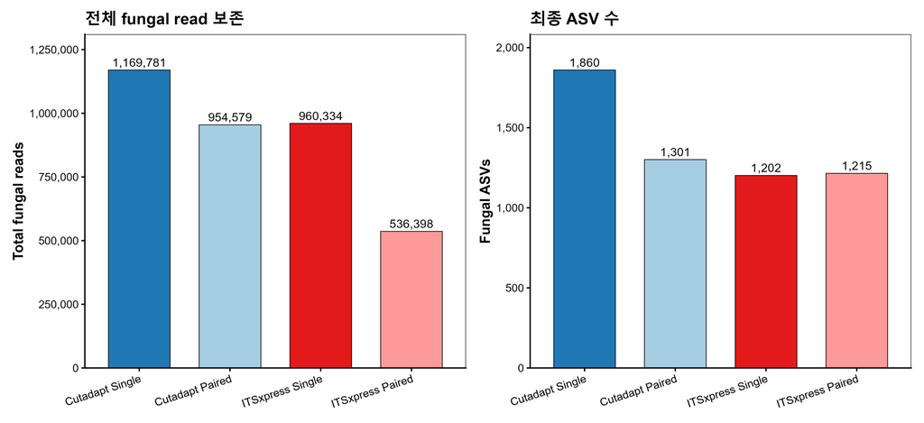

Cutadapt Single이 read와 ASV를 가장 많이 보존하였다. ITSxpress에서는 Single과 Paired의 ASV 수가 유사하지만, Paired에서 총 read가 크게 감소하였다.

# 3 3. Sample별 read depth와 observed ASV

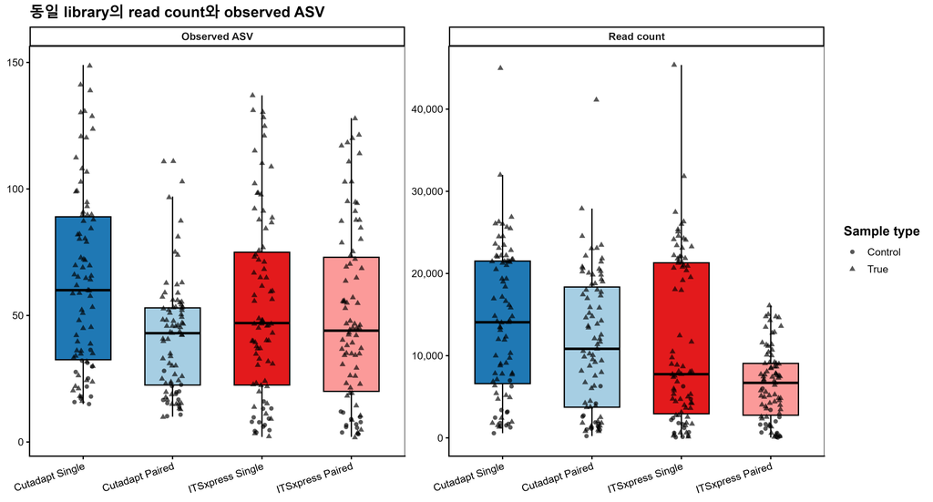

## 3.1 Paired pipeline comparison

| Comparison | Metric | N_Pairs | Median_Method_1 | Median_Method_2 | Median_Ratio_Method_2_to_1 | P_value | P_adjust_BH |
| --- | --- | --- | --- | --- | --- | --- | --- |
| Cutadapt: Single vs Paired | Read_Depth | 83 | 14066 | 10834 | 0.813 | 2.55e-15 | 8.18e-15 |
| Cutadapt: Single vs Paired | Observed_ASV | 83 | 60 | 43 | 0.677 | 5.42e-15 | 2.17e-14 |
| ITSxpress: Single vs Paired | Read_Depth | 83 | 7748 | 6692 | 0.909 | 4.09e-15 | 8.18e-15 |
| ITSxpress: Single vs Paired | Observed_ASV | 83 | 47 | 44 | 0.934 | 4.78e-14 | 9.57e-14 |
| Single-end: Cutadapt vs ITSxpress | Read_Depth | 83 | 14066 | 7748 | 0.756 | 4.99e-13 | 4.99e-13 |
| Single-end: Cutadapt vs ITSxpress | Observed_ASV | 83 | 60 | 47 | 0.819 | 1.9e-13 | 2.54e-13 |
| Paired-end: Cutadapt vs ITSxpress | Read_Depth | 83 | 10834 | 6692 | 0.732 | 3.98e-14 | 5.31e-14 |
| Paired-end: Cutadapt vs ITSxpress | Observed_ASV | 83 | 43 | 44 | 1.077 | 0.00555 | 0.00555 |

Wilcoxon p-value는 pipeline이 동일 sample 전체에 일관되게 적용되었는지를 나타낸다. 효과의 실제 크기는 `Median_Ratio_Method_2_to_1`과 원자료 분포로 판단해야 한다.

# 4 4. ASV sequence length와 taxonomy resolution

| Method | ASVs | Median_Length | Q1_Length | Q3_Length | Min_Length | Max_Length | Total_Reads |
| --- | --- | --- | --- | --- | --- | --- | --- |
| Cutadapt Paired | 1301 | 335 | 284 | 355 | 33 | 516 | 954579 |
| Cutadapt Single | 1860 | 281 | 278 | 281 | 26 | 282 | 1169781 |
| ITSxpress Paired | 1215 | 191 | 160.5 | 208 | 56 | 369 | 536398 |
| ITSxpress Single | 1202 | 172 | 159 | 173 | 30 | 176 | 960334 |

- Cutadapt Single의 중앙 길이는 281 bp, Cutadapt Paired는 335 bp였다.
- ITSxpress Single의 중앙 길이는 172 bp, ITSxpress Paired는 191 bp였다.
- ITSxpress는 ITS2 core를 추출하므로 Cutadapt보다 짧은 것이 예상되는 결과이다.
- Single-end는 read 길이 상한 때문에 길이 분포가 좁으며, paired-end는 더 긴 amplicon을 표현할 수 있다.

| Method | ASV | Kingdom | Phylum | Class | Order | Family | Genus | Species |
| --- | --- | --- | --- | --- | --- | --- | --- | --- |
| Cutadapt Single | 1860 | 1 | 7 | 29 | 84 | 221 | 389 | 577 |
| Cutadapt Paired | 1301 | 1 | 7 | 27 | 73 | 181 | 299 | 431 |
| ITSxpress Single | 1202 | 1 | 6 | 30 | 87 | 223 | 397 | 611 |
| ITSxpress Paired | 1215 | 1 | 6 | 30 | 87 | 222 | 394 | 598 |

Species label 수만으로 분류 정확도를 판단할 수는 없다. 동일 서열이 database 또는 trimming 범위에 따라 다른 label을 받을 수 있으므로 ASV sequence family와 BLAST 결과를 함께 확인하였다.

# 5 5. Aitchison community structure

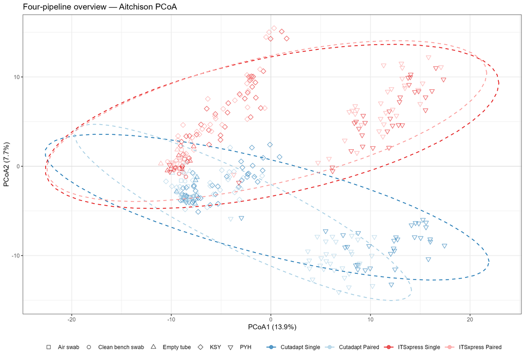

## 5.1 2×2 factorial PERMANOVA

| Term | Df | SumOfSqs | R2 | F | P_value | P_adjust_BH |
| --- | --- | --- | --- | --- | --- | --- |
| Trimming | 1 | 10536.17626478961 | 0.05787324481698911 | 20.85166313097193 | 0.001 | 0.001 |
| Read_Mode | 1 | 3268.658474880101 | 0.01795412940955005 | 6.468852047983212 | 0.001 | 0.001 |
| Trimming:Read_Mode | 1 | 2515.50852118695 | 0.01381721763448322 | 4.978327523066268 | 0.001 | 0.001 |

Trimming, read mode 및 interaction은 모두 permutation p=0.001이었으나, 설명력은 각각 약 5.8%, 1.8%, 1.4%였다. p-value뿐 아니라 작은 R²를 함께 해석해야 한다.

## 5.2 사전 지정 pairwise comparison

| Comparison | Method_1 | Method_2 | N_Pairs | PERMANOVA_R2 | PERMANOVA_P | Betadisper_P | Procrustes_r | PROTEST_P | PERMANOVA_P_BH | Betadisper_P_BH |
| --- | --- | --- | --- | --- | --- | --- | --- | --- | --- | --- |
| Cutadapt: Single vs Paired | Cutadapt Single | Cutadapt Paired | 83 | 0.05346912964616342 | 0.001 | 0.006 | 0.9759719230073464 | 0.001 | 0.001 | 0.024 |
| ITSxpress: Single vs Paired | ITSxpress Single | ITSxpress Paired | 83 | 0.01526592363894063 | 0.001 | 0.779 | 0.9956750802490124 | 0.001 | 0.001 | 0.873 |
| Single-end: Cutadapt vs ITSxpress | Cutadapt Single | ITSxpress Single | 83 | 0.06207102798809141 | 0.001 | 0.873 | 0.9865411116029164 | 0.001 | 0.001 | 0.873 |
| Paired-end: Cutadapt vs ITSxpress | Cutadapt Paired | ITSxpress Paired | 83 | 0.08548757903213391 | 0.001 | 0.016 | 0.9555645028328772 | 0.001 | 0.001 | 0.032 |

Procrustes correlation은 모두 높아 전반적인 sample 배치는 보존되었다. 다만 Cutadapt Single–Paired와 paired-end Cutadapt–ITSxpress 비교에서는 betadisper도 차이를 보여, PERMANOVA를 centroid 차이만으로 단정하면 안 된다.

# 6 6. Species 검출 및 abundance 비교

## 6.1 Species overlap

| Comparison | Method_1 | Method_2 | Detected_Method_1 | Detected_Method_2 | Shared | Method_1_only | Method_2_only |
| --- | --- | --- | --- | --- | --- | --- | --- |
| Cutadapt: Single vs Paired | Cutadapt Single | Cutadapt Paired | 577 | 431 | 350 | 227 | 81 |
| ITSxpress: Single vs Paired | ITSxpress Single | ITSxpress Paired | 611 | 598 | 569 | 42 | 29 |
| Single-end: Cutadapt vs ITSxpress | Cutadapt Single | ITSxpress Single | 577 | 611 | 491 | 86 | 120 |
| Paired-end: Cutadapt vs ITSxpress | Cutadapt Paired | ITSxpress Paired | 431 | 598 | 343 | 88 | 255 |

ITSxpress Single과 Paired는 569개 species label을 공유하여 read mode 간 overlap이 가장 컸다. 반면 Cutadapt Single은 Paired보다 더 많은 species label을 검출하였다. 이는 single-end가 무조건 더 정확하다는 의미가 아니라 read retention, ASV 분할 및 taxonomy assignment가 함께 변한 결과이다.

## 6.2 주요 paired abundance difference

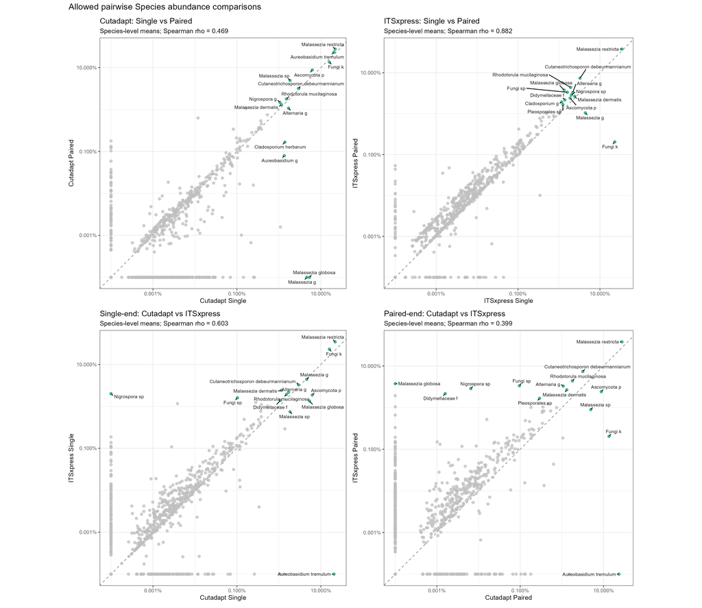

| Species | Comparison | Method_1 | Method_2 | N_Pairs | Mean_Method_1 | Mean_Method_2 | Mean_Difference_2_minus_1 | P_value | P_adjust_BH |
| --- | --- | --- | --- | --- | --- | --- | --- | --- | --- |
| Malassezia restricta | Cutadapt: Single vs Paired | Cutadapt Single | Cutadapt Paired | 83 | 0.2190160573572291 | 0.2761919569292295 | 0.05717589957200041 | 2.387180885093001e-14 | 3.342053239130203e-13 |
| Malassezia globosa | Cutadapt: Single vs Paired | Cutadapt Single | Cutadapt Paired | 83 | 0.05351864817132679 | 0 | -0.05351864817132679 | 1.679106030999023e-12 | 8.204237187166973e-12 |
| Cladosporium herbarum | Cutadapt: Single vs Paired | Cutadapt Single | Cutadapt Paired | 83 | 0.01391491269651221 | 0.00167247620800938 | -0.01224243648850282 | 1.758050825821494e-12 | 8.204237187166973e-12 |
| Malassezia g | Cutadapt: Single vs Paired | Cutadapt Single | Cutadapt Paired | 83 | 0.04618039268870366 | 0 | -0.04618039268870366 | 2.452427773137773e-11 | 8.583497205982207e-11 |
| Aureobasidium tremulum | Cutadapt: Single vs Paired | Cutadapt Single | Cutadapt Paired | 83 | 0.2053446463677161 | 0.2335763184443253 | 0.02823167207660918 | 1.573252077988142e-09 | 4.405105818366799e-09 |
| Malassezia dermatis | Cutadapt: Single vs Paired | Cutadapt Single | Cutadapt Paired | 83 | 0.01150656486736762 | 0.01311741818910338 | 0.00161085332173575 | 2.694407352402341e-07 | 6.286950488938795e-07 |
| Aureobasidium g | Cutadapt: Single vs Paired | Cutadapt Single | Cutadapt Paired | 83 | 0.01348017056670083 | 0.0007945138461303514 | -0.01268565672057048 | 2.012528480926365e-06 | 4.025056961852731e-06 |
| Rhodotorula mucilaginosa | Cutadapt: Single vs Paired | Cutadapt Single | Cutadapt Paired | 83 | 0.01516410670616033 | 0.01782018518648256 | 0.00265607848032223 | 3.013011565991952e-06 | 5.272770240485915e-06 |
| Alternaria g | Cutadapt: Single vs Paired | Cutadapt Single | Cutadapt Paired | 83 | 0.01699687558519628 | 0.01077490750982899 | -0.00622196807536728 | 0.0002633252680733851 | 0.0004096170836697102 |
| Cutaneotrichosporon debeurmannianum | Cutadapt: Single vs Paired | Cutadapt Single | Cutadapt Paired | 83 | 0.02930488108964261 | 0.03171382379055958 | 0.00240894270091696 | 0.0003605430583676343 | 0.0005047602817146881 |

[output cut: 30 more lines]

# 7 7. Sample별 species composition

아래 그림은 동일 sample을 네 pipeline으로 처리했을 때의 TSS relative composition을 보여준다. 색은 동일 taxon에 대해 유지되며, 방법별 read depth 차이와 별개로 조성 이동을 확인하기 위한 그림이다.

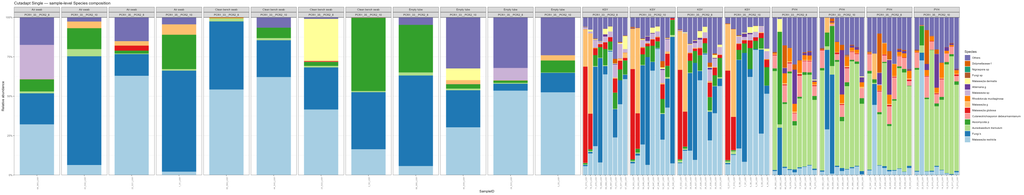

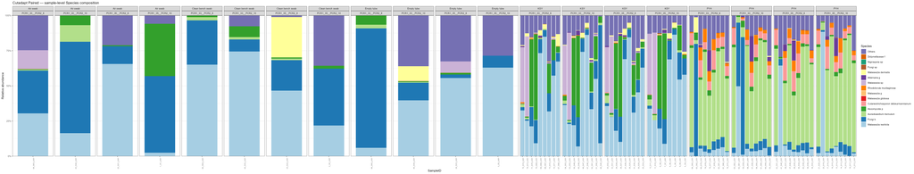

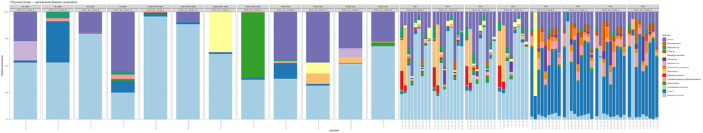

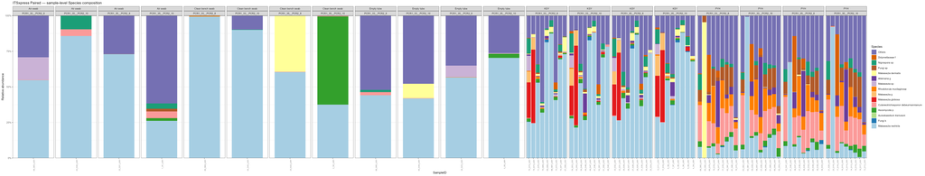

# 8 8. ASV sequence family 비교

서로 다른 pipeline에서는 동일 생물학적 서열 구간이라도 ASV ID가 달라진다. 따라서 exact ASV ID가 아니라, 긴 서열 내부에 짧은 서열이 정확히 포함되는 관계를 이용해 sequence family를 구성하였다.

| Metric | N |
| --- | --- |
| Raw ASVs across four pipelines | 5578 |
| Exact-containment edges | 4257 |
| ASV sequence families | 2136 |
| Families represented in &gt;=2 pipelines | 1379 |
| Single-pipeline families | 757 |
| Ambiguous families | 195 |

총 5,578개 pipeline-specific ASV가 2,136개 sequence family로 묶였고, 이 중 1,379개 family가 둘 이상의 pipeline에 존재하였다. 195개 family는 한 pipeline 안에서 복수 ASV가 연결되는 ambiguous family이므로, 개별 ASV의 1:1 대응으로 해석하지 않았다.

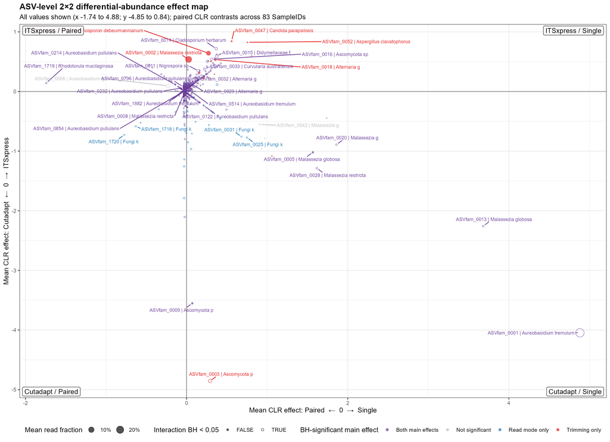

# 9 9. Aureobasidium-like family: Single/Paired와 BLAST 통합 검증

## 9.1 네 pipeline에서의 회수

| Method | ASVs | Total_Reads | Length_Range_bp | Taxonomy |
| --- | --- | --- | --- | --- |
| Cutadapt Single | 2 | 398919 | 281–281 | Aureobasidium tremulum |
| Cutadapt Paired | 5 | 389448 | 303–323 | Aureobasidium tremulum |
| ITSxpress Single | 1 | 403343 | 155–155 | Fungi k |
| ITSxpress Paired | 0 | 0 | Not detected | Not detected |

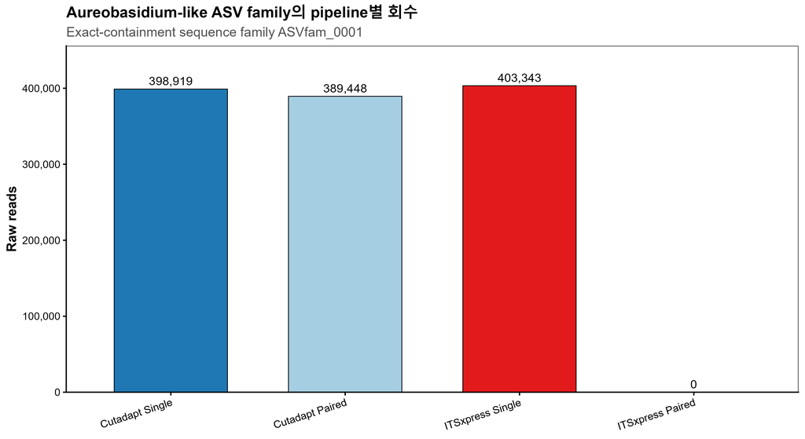

이 family는 Cutadapt Single 398,919 reads, Cutadapt Paired 389,448 reads 및 ITSxpress Single 403,343 reads로 강하게 회수되었지만 ITSxpress Paired에서는 검출되지 않았다. 특히 ITSxpress Single에서는 동일 family가 `Fungi_k`로 분류되어, taxonomy label만 비교하면 이 대응 관계를 놓치게 된다.

따라서 기존 Aureobasidium 소실은 ITSxpress trimming 자체의 보편적 실패라기보다, **ITSxpress 결과를 paired-end DADA2로 처리할 때 한쪽 mate가 지나치게 짧아지는 문제**와 일치한다.

## 9.2 NCBI BLAST 결과

| Query | Query_length_bp | Accession | Scientific_name | Query_cover_percent | Percent_identity | E_value | NCBI_BLAST_RID |
| --- | --- | --- | --- | --- | --- | --- | --- |
| Cutadapt full ASV | 303 | MT102824.1 | Aureobasidium pullulans | 100 | 100 | 2e-154 | D3324MYM014 |
| Cutadapt full ASV | 303 | PV707144.1 | Aureobasidium melanogenum | 100 | 100 | 2e-154 | D3324MYM014 |
| ITSxpress-trimmed core | 155 | MT102824.1 | Aureobasidium pullulans | 100 | 100 | 2e-72 | D3324MYM014 |
| ITSxpress-trimmed core | 155 | PV707144.1 | Aureobasidium melanogenum | 100 | 100 | 2e-72 | D3324MYM014 |

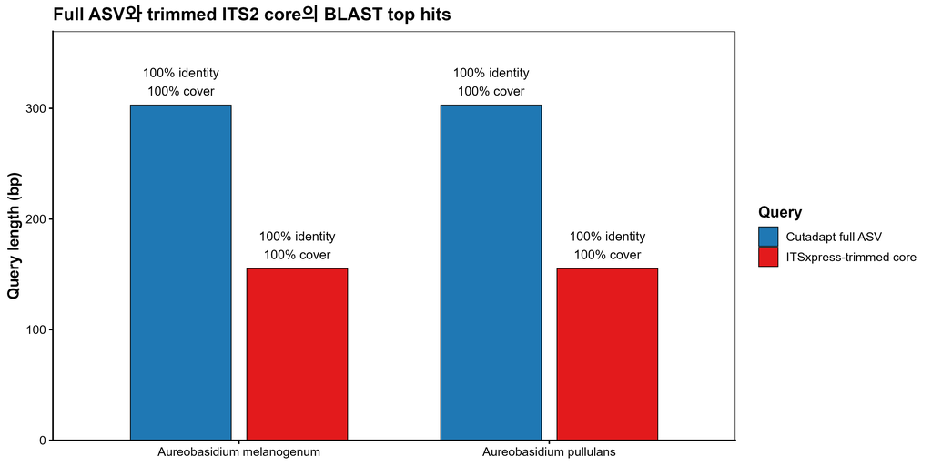

303-bp full ASV와 155-bp ITS2 core 모두 `A. pullulans` 및 `A. melanogenum`에 대해 100% query cover와 100% identity를 보였다. 따라서 trimming 후에도 Aureobasidium 수준의 동정 신호는 유지되지만, 이 서열만으로 `A. tremulum`을 유일한 species로 확정할 수 없다.

보고서와 논문에서는 이 family를 **Aureobasidium-like ASV**, **Aureobasidium spp.**, 또는 **A. pullulans/melanogenum complex**로 보수적으로 기술하는 것이 적절하다. UNITE의 *A. tremulum* label은 classifier 결과로 별도 병기할 수 있다.

# 10 10. 통합 결론

1. **Read retention:** Single-end가 두 trimming 방법 모두에서 paired-end보다 더 많은 read를 보존하였다.
2. **ASV richness:** Cutadapt Single이 가장 많은 ASV를 검출하였다. ITSxpress Single과 Paired의 전체 ASV 수는 비슷했지만 sample별 read depth는 Paired가 낮았다.
3. **Community structure:** 네 pipeline의 전체 sample 배치는 높은 Procrustes correlation으로 대체로 유지되었지만, trimming과 read mode 모두 작은 규모의 조성 변화를 만들었다.
4. **Taxonomy:** ITSxpress는 짧은 ITS2 core를 제공하여 일부 분류를 개선할 수 있지만, 같은 sequence family가 `Fungi_k`처럼 낮은 rank로 남기도 하므로 label만으로 pipeline을 비교하면 안 된다.
5. **Aureobasidium:** 우점 family는 Cutadapt Single/Paired와 ITSxpress Single에서 거의 동일한 규모로 회수되고 ITSxpress Paired에서만 소실되었다. 이는 paired ITSxpress–DADA2 처리의 구조적 손실을 강하게 지지한다.
6. **BLAST:** Full ASV와 trimmed core 모두 Aureobasidium을 지지하지만 species-level hit가 여러 종에서 동률이므로 `A. tremulum` 종 수준 결론은 보류해야 한다.

## 10.1 권장 분석 위치

- **Main biological analysis:** 현재 계획대로 QC20/maxEE22의 ITSxpress 결과를 사용할 경우, paired 결과만으로 결론 내리기 전에 ITSxpress Single을 sensitivity analysis로 함께 제시한다.
- **Aureobasidium 관련 결과:** ITSxpress Paired의 0 또는 낮은 abundance를 biological absence로 해석하지 않는다.
- **Taxonomic 검증:** 주요 결론을 좌우하는 ASV는 classifier label과 BLAST/sequence-family evidence를 함께 보고한다.
- **Decontam:** 본 비교에서는 실행하지 않았다. 추후 decontam threshold를 정할 때 pipeline-specific dropout을 contaminant evidence로 오인하지 않아야 한다.

# 11 11. 재현 파일

- 입력 phyloseq: `Phyloseq/phy_ITS2_*_q20_ee22_20261016.rds`
- 네 pipeline 원 비교: `Results/01_Preprocessing_2/`
- BLAST summary: `Results/01_Preprocessing/Aureobasidium_tremulum_BLAST_summary.csv`
- 본 보고서 산출물: `Results/01d_Single_Paired_BLAST_comparison/`

| File | Type |
| --- | --- |
| 01_total_reads_and_ASVs.png | png |
| 02_sample_read_and_observed_ASV.png | png |
| 03_Aureobasidium_family_pipeline_recovery.png | png |
| 04_Aureobasidium_BLAST_hits.png | png |
| Aureobasidium_family_pipeline_summary.csv | csv |

# 12 12. 한계

- Single-end와 paired-end는 동일 biological library의 기술적 재처리 결과이므로 독립 표본이 아니다.
- Exact-containment family는 서로 다른 길이의 ASV를 연결하는 실용적 방법이지만, ambiguous family는 1:1 ASV 대응이 아니다.
- BLAST 결과는 대표 Aureobasidium family에 한정되며 전체 ASV의 species annotation을 재분류한 결과가 아니다.
- BLAST top hit의 100% identity가 species 고유성을 보장하지 않는다. 동일 ITS2 서열을 공유하는 종이 존재할 수 있다.
- 본 보고서는 preprocessing 비교이며 True–Control 오염 판정이나 decontam threshold를 결정하지 않는다.